# COMPSCIX 415.2 Homework 5/Midterm

Chi Nguyen

3/2/2019

My Github repository for my assignments can be found at this URL: https://github.com/chimandy/compscix-415-2-assignments.git #*Exercises (Total Points - 30)* ##*RStudio and R Markdown (3 points)*

## *The tidyverse packages (3 points)*

1. Can you name which package is associated with each task below?
1. Plotting -ggplot2 R package
2. Data munging/wrangling - dplyr package
3. Reshaping (speading and gathering) data: tidyr package
4. Importing/exporting data : Data import: readr, data.table package Data export:readr
2. Now can you name two functions that you’ve used from each package that you listed above for these tasks?
1. Plotting:
1. ggplot
2. geom_smooth()
3. geom_point()
2. Data munging/wrangling:
1. select() - take a subset of columns
2. filter() - take a subset of rows
3. mutate() - add or modify existing columns
4. arrange() - sort the rows
5. summarize() - aggregate the data across rows (by groups)
3. Reshaping data:
1. gather()
2. spread()
3. seperate()

d.Importing/exporting data - Importing data :

1. read_csv()
2. read_delim() Exporting data:
3. write_csv()
4. write_tsv() - to write to a tab delimited file
5. write_delim() - to choose a delimiter

## *R Basics* (1.5 points)* 1.Fix this code **with the fewest number of changes possible** so it works: Incorrect code :

```r
#My_data.name___is.too00ooLong! <- c( 1 , 2   , 3 )
```

Correct code:

```r
My_data.name___is.too00ooLong <- c( 1 , 2   , 3 )
```

2.Fix this code so it works: Incorrect code:

```r
#my_string <- C('has', 'an', 'error', 'in', 'it)
```

Correct code:

```r
my_string <-c('has', 'an', 'error', 'in', 'it')
```

3.Look at the code below and comment on what happened to the values in the vector.

```r
my_vector <- c(1, 2, '3', '4', 5)
my_vector
```

```
## [1] "1" "2" "3" "4" "5"
```

The vector is converted to a character vector. Vectors, just like columns of a tibble, cannot have multiple types.

## *Data import/export (3 points)*

1. Download the rail_trail.txt file from Canvas (in the Midterm Exam section) and successfully import it into R. Prove that it was imported successfully by including your import code and taking a glimpse of the result.

```r
#file_path <- 'rail_trail.txt'
#rail_data <- read.table(file_path, sep = "|")
#glimpse(rail_data)
```

2.Export the file into a comma-separated file and name it “rail_trail.csv”. Make sure you define the path correctly so that you know where it gets saved. Then reload the file. Include your export and import code and take another glimpse.

```r
#write.csv(rail_trail, file = 'rail_trail.csv')
#rail_trail_csv <- read_csv('rail_trail.csv')
#glimpse(rail_trail_csv)
```

```r
file_path<-'rail_trail.txt'
file_path<-'rail_trail.csv'
```

## *Visualization (6 points)*

### 1. Critique this graphic: give only three examples of what is wrong with this graphic. Be concise.

1. the graphics are very sepearated amongs variables and observations and unable to represent the holistic view to analyze the meaning of whole dataset.
2. some counts of result outputs (Yes/No) from gender categories or groups ( between men and women ) might have been duplicated with counts coming from age categories. These data needs to be tidy up.

c.The lack of color codes to distinguish among different age categories and the missing counts of “no responses” to either Yes or No from all categories. ###2:Reproduce this graphic using the diamonds data set.

```r
#diamonds
```

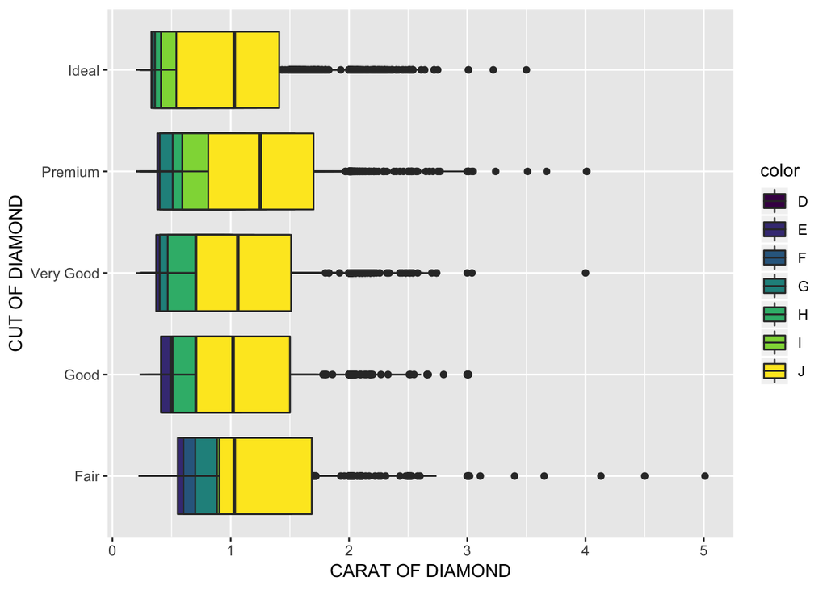

```r
library(ggplot2)
ggplot(data = diamonds, mapping = aes(x = cut, y = carat, fill = color)) +
geom_boxplot(position="identity")+
coord_flip()+
xlab('CUT OF DIAMOND')+
ylab('CARAT OF DIAMOND')
```

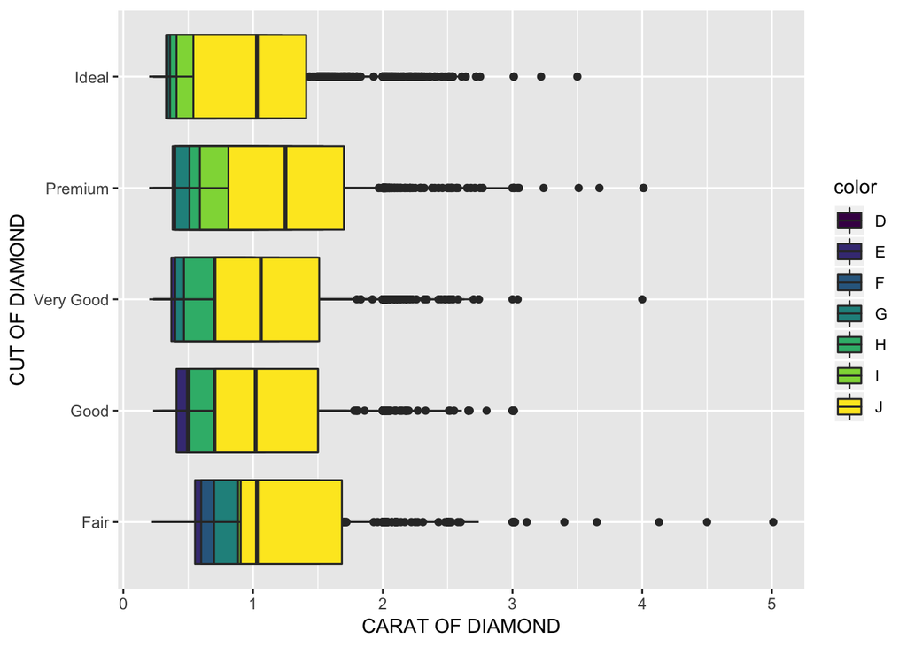

```r
ggplot(data = diamonds, mapping = aes(x = cut, y = carat, fill = color)) +
geom_boxplot(position="identity")+
coord_flip()+
xlab('CUT OF DIAMOND')+
ylab('CARAT OF DIAMOND')
```

[output not shown]

## *Data munging and wrangling (6 points)*

### 1. Is this data “tidy”? If yes, leave it alone and go to the next problem. If no, make it tidy. Note: thisdata set is called table2 and is available in the tidyverse package. It should be ready for you to use after you’ve loaded the tidyverse package.

*Problem*: This data above is not tidy because each observation name like “Afghanistan”, “Brazil”, “China”" under country category with the same year are spreading cross two rows with 2 different values for cases and population under type variables. To tidy this up, we should spread “cases” and “population”under “type” variable into 2 seperated variables " cases" and population as below:

*Untidy orginal table2 data set*

```r
library(tidyverse)
glimpse(table2)
```

```
## Observations: 12
## Variables: 4
## $ country <chr> "Afghanistan", "Afghanistan", "Afghanistan", "Afghanista…
## $ year    <int> 1999, 1999, 2000, 2000, 1999, 1999, 2000, 2000, 1999, 19…
## $ type    <chr> "cases", "population", "cases", "population", "cases", "…
## $ count   <int> 745, 19987071, 2666, 20595360, 37737, 172006362, 80488, …
```

*Tidy table2 data set*

```r
table2_tidy <-table2 %>%
    spread(key = type, value = count)
```

```r
table2_tidy
```

```
## # A tibble: 6 x 4
##   country      year  cases population
##   <chr>       <int>  <int>      <int>
## 1 Afghanistan  1999    745   19987071
## 2 Afghanistan  2000   2666   20595360
## 3 Brazil       1999  37737  172006362
## 4 Brazil       2000  80488  174504898
## 5 China        1999 212258 1272915272
## 6 China        2000 213766 1280428583
```

### 2.Create a new column in the diamonds data set called price_per_carat that shows the price of each diamond per carat (hint: divide). Only show me the code, not the output.

```r
diamonds%>%
  mutate(price_per_carat=price/carat)
```

```
## # A tibble: 53,940 x 11
##    carat cut   color clarity depth table price     x     y     z
##    <dbl> <ord> <ord> <ord>   <dbl> <dbl> <int> <dbl> <dbl> <dbl>
##  1 0.23  Ideal E     SI2      61.5    55   326  3.95  3.98  2.43
##  2 0.21  Prem… E     SI1      59.8    61   326  3.89  3.84  2.31
##  3 0.23  Good  E     VS1      56.9    65   327  4.05  4.07  2.31
##  4 0.290 Prem… I     VS2      62.4    58   334  4.2   4.23  2.63
##  5 0.31  Good  J     SI2      63.3    58   335  4.34  4.35  2.75
##  6 0.24  Very… J     VVS2     62.8    57   336  3.94  3.96  2.48
##  7 0.24  Very… I     VVS1     62.3    57   336  3.95  3.98  2.47
##  8 0.26  Very… H     SI1      61.9    55   337  4.07  4.11  2.53
##  9 0.22  Fair  E     VS2      65.1    61   337  3.87  3.78  2.49
## 10 0.23  Very… H     VS1      59.4    61   338  4     4.05  2.39
## # … with 53,930 more rows, and 1 more variable: price_per_carat <dbl>
```

### 3. For each cut of diamond in the diamonds data set, how many diamonds, and what proportion, have aprice > 10000 and a carat < 1.5? There are several ways to get to an answer, but your solution must use the data wrangling verbs from the tidyverse in order to get credit.

```r
diamonds%>%
  group_by(cut)%>%
  summarize(count_cut_of_diamond=sum(price>10000 & carat<1.5),
            prop_of_diamond=count_cut_of_diamond/n())
```

```
## # A tibble: 5 x 3
##   cut       count_cut_of_diamond prop_of_diamond
##   <ord>                    <int>           <dbl>
## 1 Fair                         4         0.00248
## 2 Good                        17         0.00347
## 3 Very Good                  155         0.0128
## 4 Premium                    173         0.0125
## 5 Ideal                      485         0.0225
```

Below is the tibble resul for the above code:

# A tibble: 5 x 3

cut count_cut_of_diamond prop_of_diamond 1 Fair 4 0.00248 2 Good 17 0.00347 3 Very Good 155 0.0128 4 Premium 173 0.0125 5 Ideal 485 0.0225

• Do the results make sense? Why?

Yes, we do need to wary and learn these numbers further across the whole data set to find out if the previous study is also true for the whole data set. If we try to find out the avg_price_per_carat for each cut of diamond, it shows as below that very good and premium catogries have higher avarage price than ideal category. It proves that it is not necessarily true and certain that the higher price is paid for same size of carat, the higher quality of the cut will be in general.

```r
diamonds %>%
  mutate(price_per_carat=price/carat)%>%
  group_by(cut) %>%
  summarize(avg_price_per_carat = mean(price_per_carat, na.rm = TRUE))
```

```
## # A tibble: 5 x 2
##   cut       avg_price_per_carat
##   <ord>                   <dbl>
## 1 Fair                    3767.
## 2 Good                    3860.
## 3 Very Good               4014.
## 4 Premium                 4223.
## 5 Ideal                   3920.
```